# Jakob Bindas CS 1675 Final Project

2024-04-12

## Final Project: Regression

This Rmd file provides my solutions to the regression portion of tasks. Those for classification related tasks are found in Bindas_Jakob_Classification.Rmd

Load in packages

```r
library(caret)
library(tidyverse)
```

Load in the data. Important response names are $\textbf{response}$ and $\textbf{outcome}$. $\textbf{response}$ is used for the regression tasks and $\textbf{outcome}$ is used for the classification tasks (event = 1, non-event = 0; popular vs less popular paints)

```r
# Mutuate the original dataframe to also contain the logit response, y
df <- readr::read_csv('paint_project_train_data-1.csv', col_names = TRUE) %>%
  mutate(
    y = boot::logit((response - 0) / (100 - 0))
  )
df %>% head()
```

```
## # A tibble: 6 × 9
##       R     G     B Lightness Saturation   Hue response outcome     y
##   <dbl> <dbl> <dbl> <chr>     <chr>      <dbl>    <dbl>   <dbl> <dbl>
## 1   172    58    62 dark      bright         4       12       1 -1.99
## 2    26    88   151 dark      bright        31       10       1 -2.20
## 3   172    94    58 dark      bright         8       16       1 -1.66
## 4    28    87   152 dark      bright        32       10       0 -2.20
## 5   170    66    58 dark      bright         5       11       0 -2.09
## 6   175    89    65 dark      bright         6       16       0 -1.66
```

## A. Linear Models

```r
# Intercept only
mod_01 <- lm(y ~ 1, data=df)

# Categorical only - linear additive
mod_02 <- lm(y ~ Lightness + Saturation, data=df)

# Continuous only - linear additive
mod_03 <- lm(y ~ R + G + B + Hue, data=df)

# Continuous only - linear additive
mod_04 <- lm(y ~ R + G + B + Hue + Lightness + Saturation, data=df)

# Interation of categorical with all continuous inputs
mod_05 <- lm(y ~ Lightness : (R + G + B + Hue) + Saturation : (R + G + B + Hue), data=df)

# Add categorical inputs to all main effect and all parwise interactions of continuous inputs
mod_06 <- lm(y ~ Lightness + Saturation + (R * G * B * Hue), data=df)

# Interaction of categorical inputs with all main effect and interactions of continuous inputs
mod_07 <- lm(y ~ Lightness : (R * G * B * Hue) + Saturation : (R * G * B * Hue), data=df)

# Nonlinear basis function - quadratic features of continuous inputs
mod_08 <- lm(y ~ I(R^2) + I(G^2) + I(B^2) + I(Hue^2), data=df)

# Interactions of basis functions with other basis functions - interactions of quadratic features
mod_09 <- lm(y ~ I(R^2) * I(G^2) * I(B^2) * I(Hue^2), data=df)

# Interactions of basis functions with categorical inputs
mod_10 <- lm(y ~ Lightness : (I(R^2) + I(G^2) + I(B^2) + I(Hue^2)) + Saturation : (I(R^2) + I(G^2) + I(B^2) + I(Hue^2)), data=df)
```

```r
# Analyze model performance using broom::glance
model_performance <- function(model){
  broom::glance(model)
}
```

```r
models <- list(mod_01, mod_02, mod_03, mod_04, mod_05, mod_06, mod_07, mod_08, mod_09, mod_10)
model_numbers <- c(1, 2, 3, 4, 5, 6, 7, 8, 9, 10)

lm_results <- purrr::map_dfr(models, model_performance) %>%
  mutate(
    model_number = model_numbers
  ) %>%
  select(
    model_number, AIC, BIC
  )
lm_results
```

```
## # A tibble: 10 × 3
##    model_number    AIC    BIC
##           <dbl>  <dbl>  <dbl>
##  1            1  2655.  2665.
##  2            2   876.   942.
##  3            3 -1037. -1009.
##  4            4 -1659. -1573.
##  5            5 -1716. -1461.
##  6            6 -2294. -2157.
##  7            7 -2848. -1917.
##  8            8 -1262. -1233.
##  9            9 -2308. -2228.
## 10           10 -1730. -1475.
```

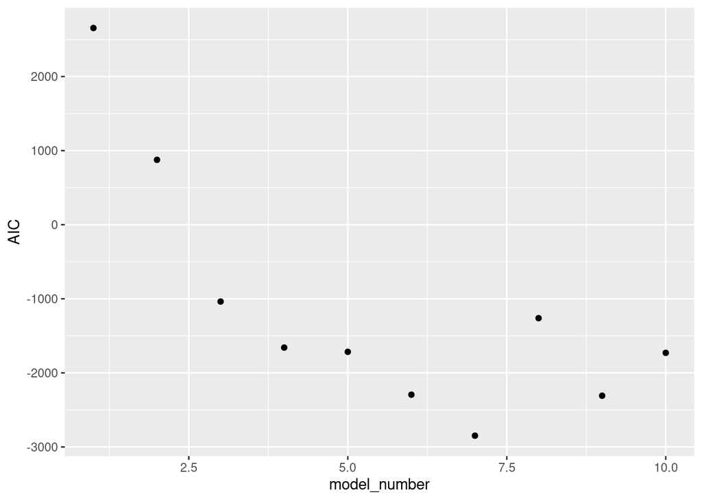

```r
# Visualize AIC and BIC
lm_results %>% ggplot(mapping=aes(x=model_number, y=AIC)) +
  geom_point()
```

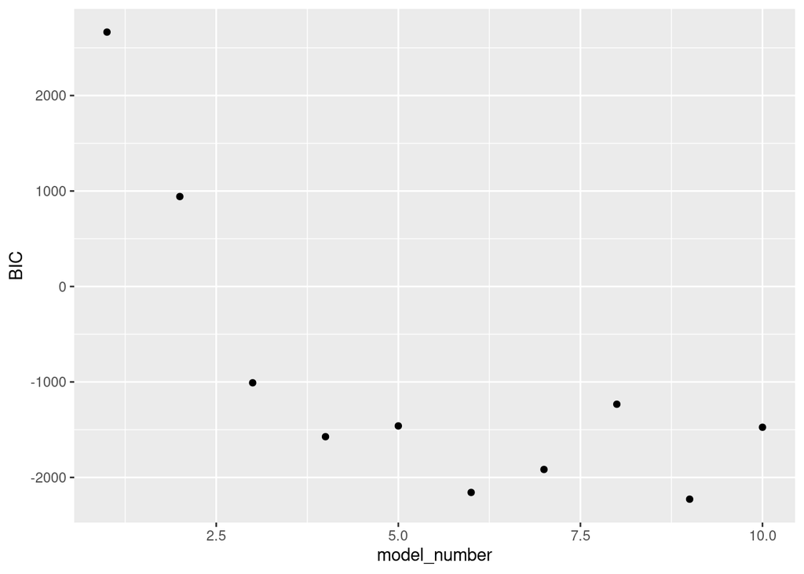

```r
lm_results %>% ggplot(mapping=aes(x=model_number, y=BIC)) +
  geom_point()
```

According to AIC, models 6, 7, 9 are the best and BIC agrees.

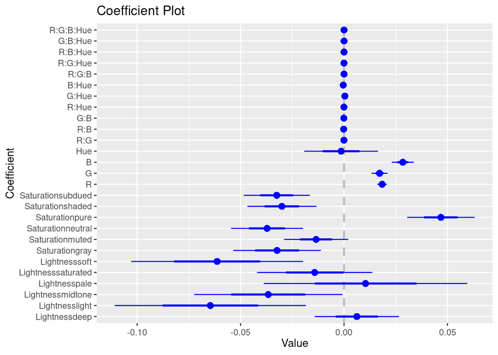

```r
# Visualize the coefficient summaries for each model
mod_06 %>%
  coefplot::coefplot(intercept=FALSE)
```

[figure not shown]

```r
mod_07 %>%
  coefplot::coefplot(intercept=FALSE)
```

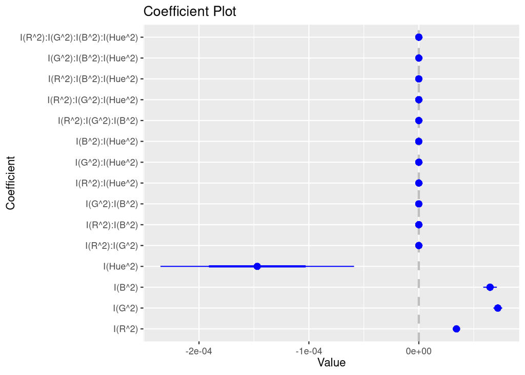

```r
mod_09 %>%
  coefplot::coefplot(intercept=FALSE)
```

The coefplot doesn’t really reveal too much for mod_07, but between mod_06 and mod_09, we can see that the Lightness and Saturation are significant for almost each of the different types, besides Lightness = saturated, pale, deep and Saturation = muted. R, G, B are also significant, but the interactions between any of the continuous variables is not.

## B. Bayesian Linear Models

I will opt to use the rstanarm approach using stan_lm

```r
library(rstanarm)
mod_06_rstan <- stan_lm(y ~ Lightness + Saturation + (R * G * B * Hue),
                        data=df,
                        prior=R2(location=1),
                        seed=12345,
                        iter=3000)
summary(mod_06_rstan)
```

```
##
## Model Info:
##  function:     stan_lm
##  family:       gaussian [identity]
##  formula:      y ~ Lightness + Saturation + (R * G * B * Hue)
##  algorithm:    sampling
##  sample:       6000 (posterior sample size)
##  priors:       see help('prior_summary')
##  observations: 835
##  predictors:   28
##
## Estimates:
##                      mean   sd   10%   50%   90%
## (Intercept)        -5.9    0.2 -6.2  -5.9  -5.7
## Lightnessdeep       0.0    0.0  0.0   0.0   0.0
## Lightnesslight     -0.1    0.0 -0.1  -0.1   0.0
## Lightnessmidtone    0.0    0.0 -0.1   0.0   0.0
## Lightnesspale       0.0    0.0  0.0   0.0   0.0
## Lightnesssaturated  0.0    0.0  0.0   0.0   0.0
## Lightnesssoft      -0.1    0.0 -0.1  -0.1   0.0
## Saturationgray      0.0    0.0  0.0   0.0   0.0
## Saturationmuted     0.0    0.0  0.0   0.0   0.0
## Saturationneutral   0.0    0.0  0.0   0.0   0.0
## Saturationpure      0.0    0.0  0.0   0.0   0.1
## Saturationshaded    0.0    0.0  0.0   0.0   0.0
## Saturationsubdued   0.0    0.0  0.0   0.0   0.0
## R                   0.0    0.0  0.0   0.0   0.0
## G                   0.0    0.0  0.0   0.0   0.0
## B                   0.0    0.0  0.0   0.0   0.0
## Hue                 0.0    0.0  0.0   0.0   0.0
## R:G                 0.0    0.0  0.0   0.0   0.0
## R:B                 0.0    0.0  0.0   0.0   0.0
## G:B                 0.0    0.0  0.0   0.0   0.0
## R:Hue               0.0    0.0  0.0   0.0   0.0
## G:Hue               0.0    0.0  0.0   0.0   0.0
## B:Hue               0.0    0.0  0.0   0.0   0.0
## R:G:B               0.0    0.0  0.0   0.0   0.0
## R:G:Hue             0.0    0.0  0.0   0.0   0.0
## R:B:Hue             0.0    0.0  0.0   0.0   0.0
## G:B:Hue             0.0    0.0  0.0   0.0   0.0
```

[output cut: 33 more lines]

```
## R:Hue              0.0  1.0  4570
## G:Hue              0.0  1.0  5060
## B:Hue              0.0  1.0  4199
## R:G:B              0.0  1.0  3716
## R:G:Hue            0.0  1.0  5513
## R:B:Hue            0.0  1.0  4284
## G:B:Hue            0.0  1.0  3760
## R:G:B:Hue          0.0  1.0  3841
## sigma              0.0  1.0  5707
## log-fit_ratio      0.0  1.0  9530
## R2                 0.0  1.0  5635
## mean_PPD           0.0  1.0  5890
## log-posterior      0.2  1.0   625
##
## For each parameter, mcse is Monte Carlo standard error, n_eff is a crude measure of effective sample size, and Rhat is the potential scale reduction factor on split chains (at convergence Rhat=1).
```

```r
mod_09_rstan <- stan_lm(y ~ I(R^2) * I(G^2) * I(B^2) * I(Hue^2),
                        data=df,
                        prior=R2(location=1),
                        seed=12345,
                        iter=3000)
summary(mod_09_rstan)
```

```
##
## Model Info:
##  function:     stan_lm
##  family:       gaussian [identity]
##  formula:      y ~ I(R^2) * I(G^2) * I(B^2) * I(Hue^2)
##  algorithm:    sampling
##  sample:       6000 (posterior sample size)
##  priors:       see help('prior_summary')
##  observations: 835
##  predictors:   16
##
## Estimates:
##                                 mean   sd   10%   50%   90%
## (Intercept)                   -3.3    0.0 -3.3  -3.3  -3.3
## I(R^2)                         0.0    0.0  0.0   0.0   0.0
## I(G^2)                         0.0    0.0  0.0   0.0   0.0
## I(B^2)                         0.0    0.0  0.0   0.0   0.0
## I(Hue^2)                       0.0    0.0  0.0   0.0   0.0
## I(R^2):I(G^2)                  0.0    0.0  0.0   0.0   0.0
## I(R^2):I(B^2)                  0.0    0.0  0.0   0.0   0.0
## I(G^2):I(B^2)                  0.0    0.0  0.0   0.0   0.0
## I(R^2):I(Hue^2)                0.0    0.0  0.0   0.0   0.0
## I(G^2):I(Hue^2)                0.0    0.0  0.0   0.0   0.0
## I(B^2):I(Hue^2)                0.0    0.0  0.0   0.0   0.0
## I(R^2):I(G^2):I(B^2)           0.0    0.0  0.0   0.0   0.0
## I(R^2):I(G^2):I(Hue^2)         0.0    0.0  0.0   0.0   0.0
## I(R^2):I(B^2):I(Hue^2)         0.0    0.0  0.0   0.0   0.0
## I(G^2):I(B^2):I(Hue^2)         0.0    0.0  0.0   0.0   0.0
## I(R^2):I(G^2):I(B^2):I(Hue^2)  0.0    0.0  0.0   0.0   0.0
## sigma                          0.1    0.0  0.1   0.1   0.1
## log-fit_ratio                  0.0    0.0  0.0   0.0   0.0
## R2                             1.0    0.0  1.0   1.0   1.0
##
## Fit Diagnostics:
##            mean   sd   10%   50%   90%
## mean_PPD -0.1    0.0 -0.1  -0.1  -0.1
##
## The mean_ppd is the sample average posterior predictive distribution of the outcome variable (for details see help('summary.stanreg')).
##
## MCMC diagnostics
```

[output cut: 9 more lines]

```
## I(R^2):I(Hue^2)               0.0  1.0  6202
## I(G^2):I(Hue^2)               0.0  1.0  5260
## I(B^2):I(Hue^2)               0.0  1.0  4892
## I(R^2):I(G^2):I(B^2)          0.0  1.0  3650
## I(R^2):I(G^2):I(Hue^2)        0.0  1.0  5403
## I(R^2):I(B^2):I(Hue^2)        0.0  1.0  5241
## I(G^2):I(B^2):I(Hue^2)        0.0  1.0  4024
## I(R^2):I(G^2):I(B^2):I(Hue^2) 0.0  1.0  3732
## sigma                         0.0  1.0  4079
## log-fit_ratio                 0.0  1.0  8811
## R2                            0.0  1.0  3993
## mean_PPD                      0.0  1.0  6300
## log-posterior                 0.1  1.0   834
##
## For each parameter, mcse is Monte Carlo standard error, n_eff is a crude measure of effective sample size, and Rhat is the potential scale reduction factor on split chains (at convergence Rhat=1).
```

We can analyze model performance here by analyzing the R^2 values for each model.

```r
get_rsquared <- function(model, model_name)
{
  tibble::tibble(
    r_squared = bayes_R2(model),
    model_name = model_name
  )
}
```

```r
r_squared_df <- purrr::map2_dfr(list(mod_06_rstan, mod_09_rstan),
                             as.character(c(6,9)),
                             get_rsquared
                             )
```

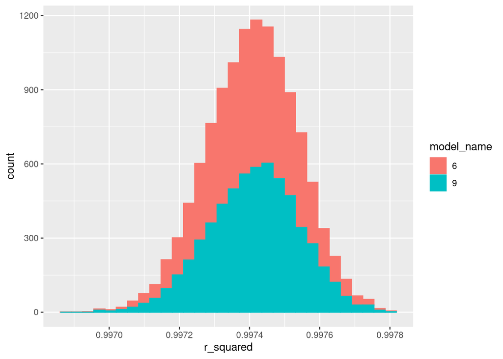

```r
r_squared_df %>%
  ggplot(mapping=aes(x=r_squared, color=model_name, fill=model_name)) +
  geom_histogram()
```

From the above plot, we can see that the rsquared values for the two models are virtually the same. We need to look at an additional parameter - I will look at WAIC, the Bayesian counterpart of AIC

```r
waic_mod_06 <- waic(mod_06_rstan)$waic
waic_mod_09 <- waic(mod_09_rstan)$waic
tibble::tibble(
  model = c(6, 9),
  waic = c(waic_mod_06, waic_mod_09)
)
```

```
## # A tibble: 2 × 2
##   model   waic
##   <dbl>  <dbl>
## 1     6 -2277.
## 2     9 -2299.
```

Again, the two models are extremely similar. However, model 9 has a slightly lower WAIC value and a slightly higher R^2 than model 6, so model 9 will be considered to be the best model.

#### Study posterior uncertainty on $\sigma$

```r
sigma_mod_06_rstan <- mod_06_rstan %>% tibble::as_tibble() %>% select(sigma)
sigma_mod_06 <- sigma(mod_06)
```

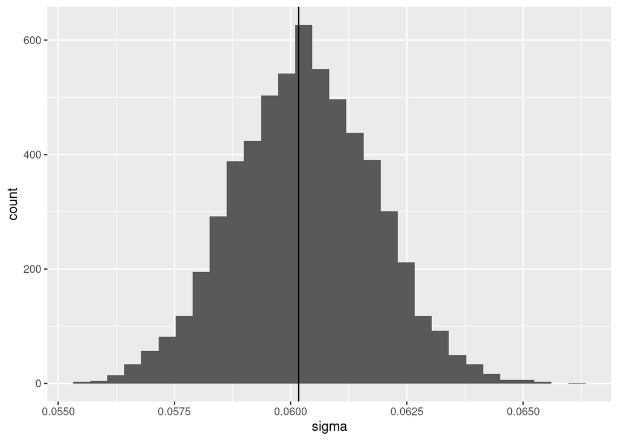

```r
sigma_mod_06_rstan %>%
  ggplot(mapping=aes(x=sigma)) +
  geom_histogram() +
  geom_vline(xintercept=sigma_mod_06)
```

The MLE on $\sigma$ from lm() is the mean of the distribution of $\sigma$ values from stan_lm(). I feel the posterior is fairly precise, as there is a FWHM on the distribution of roughly 0.005, which is indicative of a tight posterior distribution on $\sigma$.

## C. Linear Models Predictions

```r
# Define the visualization grid: primary variable is G (the variable with the strongest impact from the exploration) and Saturation as the secondary
viz_grid <- expand.grid(R = mean(df$R),
                        G = seq(50, 150, by=1),
                        B = mean(df$B),
                        Hue = mean(df$Hue),
                        Lightness = 'saturated',
                        Saturation = unique(df$Saturation)) %>%
  as.data.frame() %>% tibble::as_tibble()
```

```r
# Function defined previously in homeworks
tidy_predict <- function(mod, xnew)
{
  pred_df <- predict(mod, xnew, interval = "confidence") %>%
    as.data.frame() %>% tibble::as_tibble() %>%
    dplyr::select(pred = fit, ci_lwr = lwr, ci_upr = upr) %>%
    bind_cols(predict(mod, xnew, interval = 'prediction') %>%
                as.data.frame() %>% tibble::as_tibble() %>%
                dplyr::select(pred_lwr = lwr, pred_upr = upr))

  xnew %>% bind_cols(pred_df)
}
```

```r
# Run prediction on non-Bayesian lm() results (this is what I am more familiar working with)
pred_lm_06 <- tidy_predict(mod_06, viz_grid)
pred_lm_09 <- tidy_predict(mod_09, viz_grid)
```

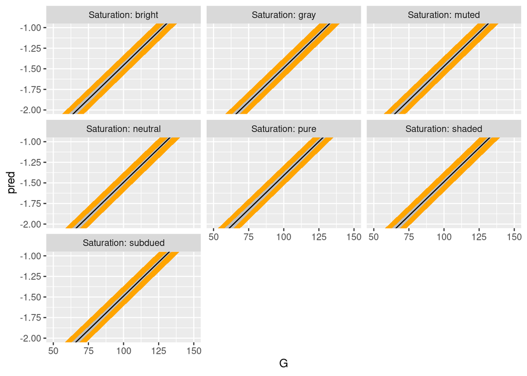

```r
# Visualize the predicted lm 06
pred_lm_06 %>%
  ggplot(mapping=aes(x=G)) +
  geom_ribbon(mapping=aes(ymin=pred_lwr, ymax=pred_upr), fill='orange') +
  geom_ribbon(mapping=aes(ymin=ci_lwr, ymax=ci_upr), fill='grey') +
  geom_line(mapping=aes(y=pred)) +
  coord_cartesian(ylim=c(-2, -1)) +
  facet_wrap(~Saturation, labeller='label_both')
```

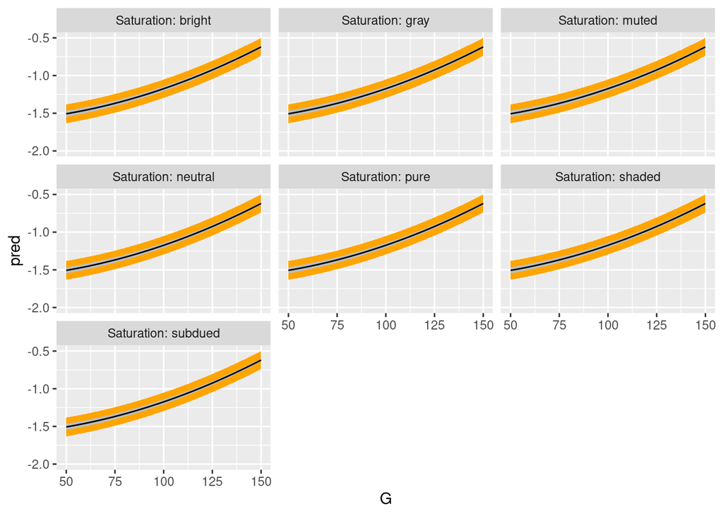

```r
# Visualize the predicted lm 09
pred_lm_09 %>%
  ggplot(mapping=aes(x=G)) +
  geom_ribbon(mapping=aes(ymin=pred_lwr, ymax=pred_upr), fill='orange') +
  geom_ribbon(mapping=aes(ymin=ci_lwr, ymax=ci_upr), fill='grey') +
  geom_line(mapping=aes(y=pred)) +
  coord_cartesian(ylim=c(-2, -0.5)) +
  facet_wrap(~Saturation, labeller='label_both')
```

The two predictive mean trends are not consistent across the two models selected. We see a clear linear relationship for mod_06 with a clear nonlinear, possibly quadratic, relationship for mod_09. When looking at each model individually, they do not vary much between each facet, but do vary between models.

## D. Train/Tune with Resampling

### Linear Models

```r
my_ctrl <- trainControl(method = "repeatedcv",
                        number = 10,
                        repeats = 3
                        )

my_metric <- 'RMSE'
```

```r
set.seed(12345)
lm_default_3 <- train(y ~ R + G + B + Hue + Lightness + Saturation,
                   data=df,
                   method='lm',
                   metric=my_metric,
                   trControl=my_ctrl
                   )
```

```r
set.seed(12345)
# NOTE: THIS MEETS A REQUIREMENT FOR LINEAR MODELS. IT IS ONE OF THE ONES SELECTED IN A
lm_default_1 <- train(y ~ Lightness + Saturation + (R * G * B * Hue),
                   data=df,
                   method='lm',
                   metric=my_metric,
                   trControl=my_ctrl
                   )
```

```r
set.seed(12345)
lm_default_2 <- train(y ~ I(R^2) * I(G^2) * I(B^2) * I(Hue^2),
                   data=df,
                   method='lm',
                   metric=my_metric,
                   trControl=my_ctrl
                   )
```

### Elastic Net

```r
set.seed(12345)
enet_default_1 <- train(y ~ Lightness + Saturation + (R * G * B * Hue),
                        data=df,
                        method='glmnet',
                        metric=my_metric,
                        preprocess=c('center', 'scale'),
                        trControl=my_ctrl)
enet_default_1
```

```
## glmnet
##
## 835 samples
##   6 predictor
##
## No pre-processing
## Resampling: Cross-Validated (10 fold, repeated 3 times)
## Summary of sample sizes: 750, 752, 751, 753, 752, 751, ...
## Resampling results across tuning parameters:
##
##   alpha  lambda       RMSE        Rsquared   MAE
##   0.10   0.002324946  0.08022305  0.9954873  0.06058303
##   0.10   0.023249462  0.08745447  0.9946893  0.06434492
##   0.10   0.232494618  0.15275081  0.9864175  0.10987032
##   0.55   0.002324946  0.08308811  0.9951649  0.06217678
##   0.55   0.023249462  0.09630166  0.9936935  0.07001048
##   0.55   0.232494618  0.20058059  0.9888444  0.14646508
##   1.00   0.002324946  0.08385924  0.9950751  0.06242334
##   1.00   0.023249462  0.10124099  0.9932238  0.07344716
##   1.00   0.232494618  0.26491596  0.9901206  0.20393213
##
## RMSE was used to select the optimal model using the smallest value.
## The final values used for the model were alpha = 0.1 and lambda = 0.002324946.
```

```r
enet_grid_1 <- expand.grid(alpha=seq(0.1, 1.0, by=0.1),
                           lambda=exp(seq(log(min(enet_default_1$results$lambda)),
                                  log(max(enet_default_1$results$lambda)),
                                  length.out=25))
)
```

```r
set.seed(12345)
enet_tune_1 <- train(y ~ Lightness + Saturation + (R * G * B * Hue),
                     data=df,
                     method='glmnet',
                     metric=my_metric,
                     tuneGrid=enet_grid_1,
                     preprocess=c('center', 'scale'),
                     trControl=my_ctrl)
```

```r
enet_tune_1$bestTune
```

```
##   alpha      lambda
## 1   0.1 0.002324946
```

```r
set.seed(12345)
enet_default_2 <- train(y ~ I(R^2) * I(G^2) * I(B^2) * I(Hue^2),
                   data=df,
                   method='glmnet',
                   metric=my_metric,
                   trControl=my_ctrl
                   )
enet_default_2
```

```
## glmnet
##
## 835 samples
##   4 predictor
##
## No pre-processing
## Resampling: Cross-Validated (10 fold, repeated 3 times)
## Summary of sample sizes: 750, 752, 751, 753, 752, 751, ...
## Resampling results across tuning parameters:
##
##   alpha  lambda       RMSE       Rsquared   MAE
##   0.10   0.002331673  0.0892222  0.9944450  0.06781846
##   0.10   0.023316725  0.1160409  0.9906734  0.08485230
##   0.10   0.233167255  0.2005571  0.9753485  0.13716882
##   0.55   0.002331673  0.1129573  0.9910804  0.08346291
##   0.55   0.023316725  0.1144727  0.9910496  0.08133824
##   0.55   0.233167255  0.2270699  0.9829193  0.15377530
##   1.00   0.002331673  0.1129766  0.9910765  0.08339786
##   1.00   0.023316725  0.1155524  0.9910202  0.08073655
##   1.00   0.233167255  0.2788216  0.9853737  0.20990601
##
## RMSE was used to select the optimal model using the smallest value.
## The final values used for the model were alpha = 0.1 and lambda = 0.002331673.
```

```r
enet_grid_2 <- expand.grid(alpha=seq(0.1, 1.0, by=0.1),
                           lambda=exp(seq(log(min(enet_default_2$results$lambda)),
                                  log(max(enet_default_2$results$lambda)),
                                  length.out=25))
)
```

```r
set.seed(12345)
enet_tune_2 <- train(y ~ I(R^2) * I(G^2) * I(B^2) * I(Hue^2),
                     data=df,
                     method='glmnet',
                     metric=my_metric,
                     tuneGrid=enet_grid_2,
                     preprocess=c('center', 'scale'),
                     trControl=my_ctrl)
```

```r
enet_tune_2$bestTune
```

```
##   alpha      lambda
## 1   0.1 0.002331673
```

```r
set.seed(12345)
enet_default_3 <- train(y ~ R + G + B + Hue + Lightness + Saturation,
                   data=df,
                   method='glmnet',
                   metric=my_metric,
                   trControl=my_ctrl
                   )
enet_default_3
```

```
## glmnet
##
## 835 samples
##   6 predictor
##
## No pre-processing
## Resampling: Cross-Validated (10 fold, repeated 3 times)
## Summary of sample sizes: 750, 752, 751, 753, 752, 751, ...
## Resampling results across tuning parameters:
##
##   alpha  lambda       RMSE        Rsquared   MAE
##   0.10   0.002324946  0.08987004  0.9943496  0.06670739
##   0.10   0.023249462  0.09413305  0.9939073  0.06893926
##   0.10   0.232494618  0.16735005  0.9879491  0.13080894
##   0.55   0.002324946  0.08979147  0.9943563  0.06695903
##   0.55   0.023249462  0.09866758  0.9934502  0.07510676
##   0.55   0.232494618  0.22231038  0.9889112  0.18103472
##   1.00   0.002324946  0.09038572  0.9942816  0.06758022
##   1.00   0.023249462  0.10611083  0.9925477  0.08257112
##   1.00   0.232494618  0.29495183  0.9786119  0.24577807
##
## RMSE was used to select the optimal model using the smallest value.
## The final values used for the model were alpha = 0.55 and lambda = 0.002324946.
```

```r
enet_grid_3 <- expand.grid(alpha=seq(0.1, 1.0, by=0.1),
                           lambda=exp(seq(log(min(enet_default_3$results$lambda)),
                                  log(max(enet_default_3$results$lambda)),
                                  length.out=25))
)
```

```r
set.seed(12345)
enet_tune_3 <- train(y ~ R + G + B + Lightness + Saturation,
                     data=df,
                     method='glmnet',
                     metric=my_metric,
                     tuneGrid=enet_grid_3,
                     preprocess=c('center', 'scale'),
                     trControl=my_ctrl)
```

```r
enet_tune_3$bestTune
```

```
##     alpha      lambda
## 101   0.5 0.002324946
```

### Neural Network

```r
set.seed(12345)
nnet_default_1 <- train(y ~ Lightness + Saturation + (R * G * B * Hue),
                   data=df,
                   method='nnet',
                   metric=my_metric,
                   trControl=my_ctrl,
                   trace=FALSE
                   )
nnet_default_1
```

```
## Neural Network
##
## 835 samples
##   6 predictor
##
## No pre-processing
## Resampling: Cross-Validated (10 fold, repeated 3 times)
## Summary of sample sizes: 750, 752, 751, 753, 752, 751, ...
## Resampling results across tuning parameters:
##
##   size  decay  RMSE      Rsquared    MAE
##   1     0e+00  1.188279         NaN  1.0115750
##   1     1e-04  1.188280  0.01659013  1.0115754
##   1     1e-01  1.108935  0.57866543  0.8946799
##   3     0e+00  1.188279         NaN  1.0115750
##   3     1e-04  1.188284  0.02173914  1.0116200
##   3     1e-01  1.115555  0.35416681  0.9082364
##   5     0e+00  1.188279         NaN  1.0115750
##   5     1e-04  1.188293  0.01803199  1.0115739
##   5     1e-01  1.054354  0.59715360  0.8169762
##
## RMSE was used to select the optimal model using the smallest value.
## The final values used for the model were size = 5 and decay = 0.1.
```

```r
set.seed(12345)
nnet_default_2 <- train(y ~ I(R^2) * I(G^2) * I(B^2) * I(Hue^2),
                   data=df,
                   method='nnet',
                   metric=my_metric,
                   trControl=my_ctrl,
                   trace=FALSE
                   )
nnet_default_2
```

```
## Neural Network
##
## 835 samples
##   4 predictor
##
## No pre-processing
## Resampling: Cross-Validated (10 fold, repeated 3 times)
## Summary of sample sizes: 750, 752, 751, 753, 752, 751, ...
## Resampling results across tuning parameters:
##
##   size  decay  RMSE      Rsquared    MAE
##   1     0e+00  1.188279         NaN  1.0115750
##   1     1e-04  1.188279  0.01446714  1.0115735
##   1     1e-01  1.183560  0.13613922  1.0046160
##   3     0e+00  1.188279         NaN  1.0115750
##   3     1e-04  1.188279  0.01799526  1.0115738
##   3     1e-01  1.177754  0.05064783  0.9967892
##   5     0e+00  1.188279         NaN  1.0115750
##   5     1e-04  1.188280  0.01773677  1.0115755
##   5     1e-01  1.177581  0.06283609  0.9963253
##
## RMSE was used to select the optimal model using the smallest value.
## The final values used for the model were size = 5 and decay = 0.1.
```

```r
set.seed(12345)
nnet_default_3 <- train(y ~ R + G + B + Lightness + Saturation,
                   data=df,
                   method='nnet',
                   metric=my_metric,
                   trControl=my_ctrl,
                   trace=FALSE
                   )
nnet_default_3
```

```
## Neural Network
##
## 835 samples
##   5 predictor
##
## No pre-processing
## Resampling: Cross-Validated (10 fold, repeated 3 times)
## Summary of sample sizes: 750, 752, 751, 753, 752, 751, ...
## Resampling results across tuning parameters:
##
##   size  decay  RMSE      Rsquared   MAE
##   1     0e+00  1.188279        NaN  1.0115750
##   1     1e-04  1.188280  0.3794383  1.0115749
##   1     1e-01  1.131029  0.3866266  0.9207269
##   3     0e+00  1.188279        NaN  1.0115750
##   3     1e-04  1.172751  0.4368198  0.9887598
##   3     1e-01  1.023992  0.6464385  0.7538508
##   5     0e+00  1.188279        NaN  1.0115750
##   5     1e-04  1.124896  0.4235917  0.9142057
##   5     1e-01  1.043631  0.5975658  0.7856722
##
## RMSE was used to select the optimal model using the smallest value.
## The final values used for the model were size = 3 and decay = 0.1.
```

```r
# Can use the same grid for the three nnets
nnet_grid <- expand.grid(
  size=c(1, 2, 3, 4, 5),
  decay=exp(seq(-6, 0, length.out=7))
)
```

```r
set.seed(12345)
nnet_tune_1 <- train(y ~ Lightness + Saturation + (R * G * B * Hue),
                     data=df,
                     method='nnet',
                     metric=my_metric,
                     tuneGrid=nnet_grid,
                     preprocess=c('center', 'scale'),
                     trControl=my_ctrl,
                     trace=FALSE)
nnet_tune_1$bestTune
```

```
##    size     decay
## 20    3 0.3678794
```

```r
set.seed(12345)
nnet_tune_2 <- train(y ~ I(R^2) * I(G^2) * I(B^2) * I(Hue^2),
                     data=df,
                     method='nnet',
                     metric=my_metric,
                     tuneGrid=nnet_grid,
                     preprocess=c('center', 'scale'),
                     trControl=my_ctrl,
                     trace=FALSE)
nnet_tune_2$bestTune
```

```
##    size      decay
## 24    4 0.01831564
```

```r
set.seed(12345)
nnet_tune_3 <- train(y ~ R + G + B + Lightness + Saturation,
                     data=df,
                     method='nnet',
                     metric=my_metric,
                     tuneGrid=nnet_grid,
                     preprocess=c('center', 'scale'),
                     trControl=my_ctrl,
                     trace=FALSE)
nnet_tune_3$bestTune
```

```
##    size      decay
## 31    5 0.01831564
```

### Random Forest

```r
set.seed(12345)
rf_default_1 <- train(y ~ Lightness + Saturation + (R * G * B * Hue),
                     data=df,
                     method='rf',
                     metric=my_metric,
                     trControl=my_ctrl,
                     importance=TRUE)

rf_default_1
```

```
## Random Forest
##
## 835 samples
##   6 predictor
##
## No pre-processing
## Resampling: Cross-Validated (10 fold, repeated 3 times)
## Summary of sample sizes: 750, 752, 751, 753, 752, 751, ...
## Resampling results across tuning parameters:
##
##   mtry  RMSE        Rsquared   MAE
##    2    0.11585703  0.9918774  0.08259833
##   14    0.05586908  0.9978686  0.04058725
##   27    0.06596984  0.9969689  0.04771318
##
## RMSE was used to select the optimal model using the smallest value.
## The final value used for the model was mtry = 14.
```

```r
set.seed(12345)
rf_default_2 <- train(y ~ I(R^2) * I(G^2) * I(B^2) * I(Hue^2),
                     data=df,
                     method='rf',
                     metric=my_metric,
                     trControl=my_ctrl,
                     importance=TRUE)

rf_default_2
```

```
## Random Forest
##
## 835 samples
##   4 predictor
##
## No pre-processing
## Resampling: Cross-Validated (10 fold, repeated 3 times)
## Summary of sample sizes: 750, 752, 751, 753, 752, 751, ...
## Resampling results across tuning parameters:
##
##   mtry  RMSE        Rsquared   MAE
##    2    0.08482511  0.9951993  0.05877330
##    8    0.05592884  0.9978575  0.04069689
##   15    0.06560176  0.9970020  0.04744747
##
## RMSE was used to select the optimal model using the smallest value.
## The final value used for the model was mtry = 8.
```

```r
set.seed(12345)
rf_default_3 <- train(y ~ R + G + B + Hue + Lightness + Saturation,
                     data=df,
                     method='rf',
                     metric=my_metric,
                     trControl=my_ctrl,
                     importance=TRUE)

rf_default_3
```

```
## Random Forest
##
## 835 samples
##   6 predictor
##
## No pre-processing
## Resampling: Cross-Validated (10 fold, repeated 3 times)
## Summary of sample sizes: 750, 752, 751, 753, 752, 751, ...
## Resampling results across tuning parameters:
##
##   mtry  RMSE        Rsquared   MAE
##    2    0.22464066  0.9765767  0.16359698
##    9    0.06825315  0.9968182  0.05046848
##   16    0.08412775  0.9950286  0.06114152
##
## RMSE was used to select the optimal model using the smallest value.
## The final value used for the model was mtry = 9.
```

### Gradient Boosted Tree

```r
set.seed(12345)
xgbTree_default_1 <- train(y ~ Lightness + Saturation + (R * G * B * Hue),
                     data=df,
                     method='xgbTree',
                     metric=my_metric,
                     trControl=my_ctrl,
                     verbosity=0,
                     nthread=1)

xgbTree_default_1$bestTune
```

```
##    nrounds max_depth eta gamma colsample_bytree min_child_weight subsample
## 54     150         3 0.3     0              0.8                1         1
```

```r
set.seed(12345)
xgbTree_default_2 <- train(y ~ I(R^2) * I(G^2) * I(B^2) * I(Hue^2),
                     data=df,
                     method='xgbTree',
                     metric=my_metric,
                     trControl=my_ctrl,
                     verbosity=0,
                     nthread=1)

xgbTree_default_2$bestTune
```

```
##    nrounds max_depth eta gamma colsample_bytree min_child_weight subsample
## 54     150         3 0.3     0              0.8                1         1
```

```r
set.seed(12345)
xgbTree_default_3 <- train(y ~ Lightness + Saturation + R + G + B + Hue,
                     data=df,
                     method='xgbTree',
                     metric=my_metric,
                     trControl=my_ctrl,
                     verbosity=0,
                     nthread=1)

xgbTree_default_3$bestTune
```

```
##    nrounds max_depth eta gamma colsample_bytree min_child_weight subsample
## 54     150         3 0.3     0              0.8                1         1
```

```r
xgbTree_grid_1 <- expand.grid(nrounds = c(75, 150, 225),
                              max_depth=c(2, 3, 4, 5, 6),
                              eta=c(0.5*xgbTree_default_1$bestTune$eta,
                                    xgbTree_default_1$bestTune$eta,
                                    1.5*xgbTree_default_1$bestTune$eta),
                              gamma=xgbTree_default_1$bestTune$gamma,
                              colsample_bytree=xgbTree_default_1$bestTune$colsample_bytree,
                              min_child_weight=xgbTree_default_1$bestTune$min_child_weight,
                              subsample=xgbTree_default_1$bestTune$subsample)

xgbTree_grid_2 <- expand.grid(nrounds = c(75, 150, 225),
                              max_depth=c(2, 3, 4, 5, 6),
                              eta=c(0.5*xgbTree_default_2$bestTune$eta,
                                    xgbTree_default_2$bestTune$eta,
                                    1.5*xgbTree_default_2$bestTune$eta),
                              gamma=xgbTree_default_2$bestTune$gamma,
                              colsample_bytree=xgbTree_default_2$bestTune$colsample_bytree,
                              min_child_weight=xgbTree_default_2$bestTune$min_child_weight,
                              subsample=xgbTree_default_2$bestTune$subsample)

xgbTree_grid_3 <- expand.grid(nrounds = c(75, 150, 225),
                              max_depth=c(2, 3, 4, 5, 6),
                              eta=c(0.5*xgbTree_default_3$bestTune$eta,
                                    xgbTree_default_3$bestTune$eta,
                                    1.5*xgbTree_default_3$bestTune$eta),
                              gamma=xgbTree_default_3$bestTune$gamma,
                              colsample_bytree=xgbTree_default_3$bestTune$colsample_bytree,
                              min_child_weight=xgbTree_default_3$bestTune$min_child_weight,
                              subsample=xgbTree_default_3$bestTune$subsample)
```

```r
set.seed(1234)
xgbTree_tune_1 <- train(y ~ Lightness + Saturation + (R * G * B * Hue),
                     data=df,
                     method='xgbTree',
                     metric=my_metric,
                     tuneGrid=xgbTree_grid_1,
                     trControl=my_ctrl,
                     verbosity=0,
                     nthread=1)

xgbTree_default_1$bestTune
```

```
##    nrounds max_depth eta gamma colsample_bytree min_child_weight subsample
## 54     150         3 0.3     0              0.8                1         1
```

```r
set.seed(1234)
xgbTree_tune_2 <- train(y ~ I(R^2) * I(G^2) * I(B^2) * I(Hue^2),
                     data=df,
                     method='xgbTree',
                     metric=my_metric,
                     tuneGrid=xgbTree_grid_2,
                     trControl=my_ctrl,
                     verbosity=0,
                     nthread=1)

xgbTree_default_2$bestTune
```

```
##    nrounds max_depth eta gamma colsample_bytree min_child_weight subsample
## 54     150         3 0.3     0              0.8                1         1
```

```r
set.seed(1234)
xgbTree_tune_3 <- train(y ~ Lightness + Saturation + R + G + B + Hue,
                     data=df,
                     method='xgbTree',
                     metric=my_metric,
                     tuneGrid=xgbTree_grid_3,
                     trControl=my_ctrl,
                     verbosity=0,
                     nthread=1)

xgbTree_default_3$bestTune
```

```
##    nrounds max_depth eta gamma colsample_bytree min_child_weight subsample
## 54     150         3 0.3     0              0.8                1         1
```

### Partial Least Squares

```r
set.seed(12345)
pls_default_1 <- train(y ~ Lightness + Saturation + (R * G * B * Hue),
                     data=df,
                     method='pls',
                     metric=my_metric,
                     preProcess=c('center', 'scale'),
                     trControl=my_ctrl)
```

```r
set.seed(12345)
pls_default_2 <- train(y ~ I(R^2) * I(G^2) * I(B^2) * I(Hue^2),
                     data=df,
                     method='pls',
                     metric=my_metric,
                     preProcess=c('center', 'scale'),
                     trControl=my_ctrl)
```

```r
set.seed(12345)
pls_default_3 <- train(y ~ R + G + B + Hue + Lightness + Saturation,
                     data=df,
                     method='pls',
                     metric=my_metric,
                     preProcess=c('center', 'scale'),
                     trControl=my_ctrl)
```

```r
pls_grid <- expand.grid(ncomp=1:10)
```

```r
set.seed(12345)
pls_tune_1 <- train(y ~ Lightness + Saturation + (R * G * B * Hue),
                     data=df,
                     method='pls',
                     metric=my_metric,
                     tuneGrid=pls_grid,
                     preProcess=c('center', 'scale'),
                     trControl=my_ctrl)
pls_tune_1
```

```
## Partial Least Squares
##
## 835 samples
##   6 predictor
##
## Pre-processing: centered (27), scaled (27)
## Resampling: Cross-Validated (10 fold, repeated 3 times)
## Summary of sample sizes: 750, 752, 751, 753, 752, 751, ...
## Resampling results across tuning parameters:
##
##   ncomp  RMSE        Rsquared   MAE
##    1     0.43300746  0.8682397  0.35840362
##    2     0.23626708  0.9607559  0.17298347
##    3     0.16727077  0.9804374  0.12889495
##    4     0.10960869  0.9915881  0.08214330
##    5     0.08965913  0.9943519  0.06653449
##    6     0.08767554  0.9946066  0.06475641
##    7     0.08638478  0.9947589  0.06431873
##    8     0.08439524  0.9949977  0.06372996
##    9     0.08380112  0.9950688  0.06336436
##   10     0.08126921  0.9953657  0.06142243
##
## RMSE was used to select the optimal model using the smallest value.
## The final value used for the model was ncomp = 10.
```

```r
set.seed(12345)
pls_tune_2 <- train(y ~ I(R^2) * I(G^2) * I(B^2) * I(Hue^2),
                     data=df,
                     method='pls',
                     metric=my_metric,
                     tuneGrid=pls_grid,
                     preProcess=c('center', 'scale'),
                     trControl=my_ctrl)
pls_tune_2
```

```
## Partial Least Squares
##
## 835 samples
##   4 predictor
##
## Pre-processing: centered (15), scaled (15)
## Resampling: Cross-Validated (10 fold, repeated 3 times)
## Summary of sample sizes: 750, 752, 751, 753, 752, 751, ...
## Resampling results across tuning parameters:
##
##   ncomp  RMSE        Rsquared   MAE
##    1     0.50424526  0.8229528  0.41581375
##    2     0.29182837  0.9400410  0.22161154
##    3     0.14072602  0.9861177  0.10573797
##    4     0.12503507  0.9891344  0.09576778
##    5     0.11916841  0.9901053  0.09257347
##    6     0.11427807  0.9909114  0.09045718
##    7     0.10210554  0.9926972  0.07962965
##    8     0.08303886  0.9951660  0.06445775
##    9     0.07248382  0.9963198  0.05481387
##   10     0.06910719  0.9966477  0.05171935
##
## RMSE was used to select the optimal model using the smallest value.
## The final value used for the model was ncomp = 10.
```

```r
set.seed(12345)
pls_tune_3 <- train(y ~ R + G + B + Hue + Lightness + Saturation,
                     data=df,
                     method='pls',
                     metric=my_metric,
                     tuneGrid=pls_grid,
                     preProcess=c('center', 'scale'),
                     trControl=my_ctrl)
pls_tune_3
```

```
## Partial Least Squares
##
## 835 samples
##   6 predictor
##
## Pre-processing: centered (16), scaled (16)
## Resampling: Cross-Validated (10 fold, repeated 3 times)
## Summary of sample sizes: 750, 752, 751, 753, 752, 751, ...
## Resampling results across tuning parameters:
##
##   ncomp  RMSE        Rsquared   MAE
##    1     0.25952506  0.9526562  0.19855065
##    2     0.17168892  0.9793318  0.13167053
##    3     0.13679071  0.9869181  0.10346751
##    4     0.10271060  0.9925807  0.07775252
##    5     0.09577797  0.9935791  0.07092201
##    6     0.09295370  0.9939549  0.06904148
##    7     0.09250079  0.9940122  0.06844111
##    8     0.09148420  0.9941482  0.06767901
##    9     0.08929535  0.9944151  0.06710481
##   10     0.08932946  0.9944112  0.06718732
##
## RMSE was used to select the optimal model using the smallest value.
## The final value used for the model was ncomp = 9.
```

### **Gaussian Process with Radial Basis Function Kernel**

```r
set.seed(12345)
gauss_default_1 <- train(y ~ Lightness + Saturation + (R * G * B * Hue),
                     data=df,
                     method='gaussprRadial',
                     metric=my_metric,
                     preProcess=c('center', 'scale'),
                     trControl=my_ctrl)
```

```r
set.seed(12345)
gauss_default_2 <- train(y ~ I(R^2) * I(G^2) * I(B^2) * I(Hue^2),
                     data=df,
                     method='gaussprRadial',
                     metric=my_metric,
                     preProcess=c('center', 'scale'),
                     trControl=my_ctrl)
```

```r
set.seed(12345)
gauss_default_3 <- train(y ~ R + G + B + Hue + Lightness + Saturation,
                     data=df,
                     method='gaussprRadial',
                     metric=my_metric,
                     preProcess=c('center', 'scale'),
                     trControl=my_ctrl)
```

```r
gauss_grid_1 <- expand.grid(sigma=c(0.5*gauss_default_1$bestTune$sigma,
                    gauss_default_1$bestTune$sigma,
                    2*gauss_default_1$bestTune$sigma))

gauss_grid_2 <- expand.grid(sigma=c(0.5*gauss_default_2$bestTune$sigma,
                    gauss_default_2$bestTune$sigma,
                    2*gauss_default_2$bestTune$sigma))

gauss_grid_3 <- expand.grid(sigma=c(0.5*gauss_default_3$bestTune$sigma,
                    gauss_default_3$bestTune$sigma,
                    2*gauss_default_3$bestTune$sigma))
```

```r
set.seed(12345)
gauss_tune_1 <- train(y ~ Lightness + Saturation + (R * G * B * Hue),
                     data=df,
                     method='gaussprRadial',
                     metric=my_metric,
                     tuneGrid=gauss_grid_1,
                     preProcess=c('center', 'scale'),
                     trControl=my_ctrl)
```

```r
set.seed(12345)
gauss_tune_2 <- train(y ~ I(R^2) * I(G^2) * I(B^2) * I(Hue^2),
                     data=df,
                     method='gaussprRadial',
                     metric=my_metric,
                     tuneGrid=gauss_grid_2,
                     preProcess=c('center', 'scale'),
                     trControl=my_ctrl)
```

```r
set.seed(12345)
gauss_tune_3 <- train(y ~ R + G + B + Hue + Lightness + Saturation,
                     data=df,
                     method='gaussprRadial',
                     metric=my_metric,
                     tuneGrid=gauss_grid_3,
                     preProcess=c('center', 'scale'),
                     trControl=my_ctrl)
```

### Compare each model

```r
master_model_list <- resamples(list(
  lm1=lm_default_1,
  lm2=lm_default_2,
  lm3=lm_default_3,
  enet1=enet_tune_1,
  enet2=enet_tune_2,
  enet3=enet_tune_3,
  nnet1=nnet_tune_1,
  nnet2=nnet_tune_2,
  nnet3=nnet_tune_3,
  rf1=rf_default_1,
  rf2=rf_default_2,
  rf3=rf_default_3,
  xgbTree1=xgbTree_tune_1,
  xgbTree2=xgbTree_tune_2,
  xgbTree3=xgbTree_tune_3,
  pls1=pls_tune_1,
  pls2=pls_tune_2,
  pls3=pls_tune_3,
  gauss1=gauss_tune_1,
  gauss2=gauss_tune_2,
  gauss3=gauss_tune_3
))
```

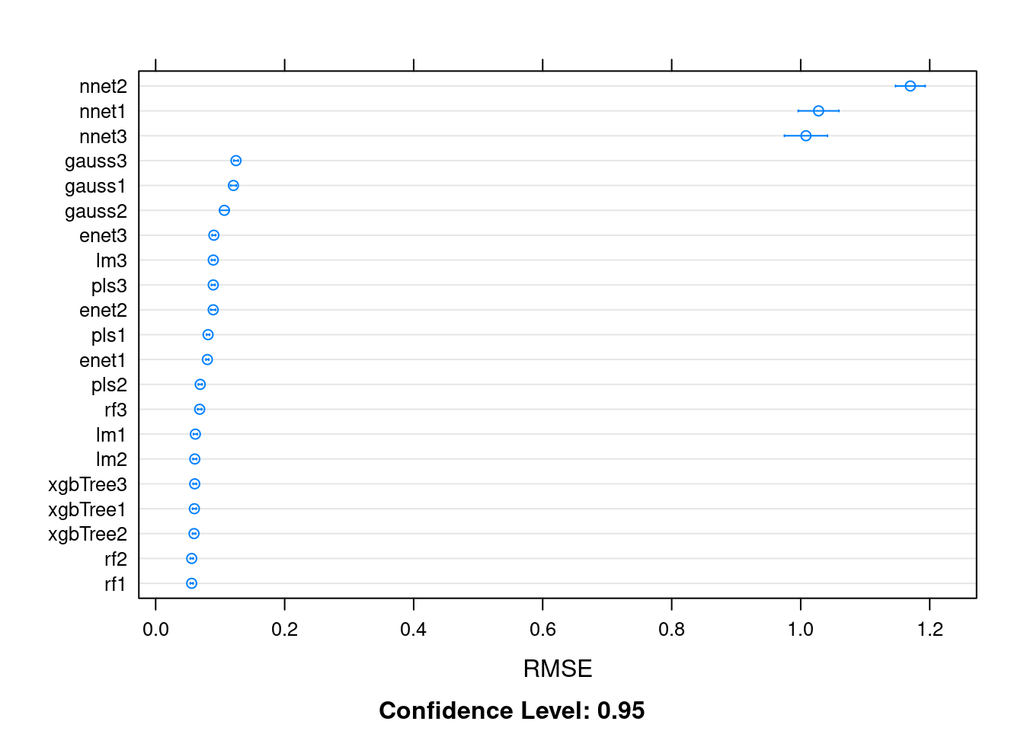

```r
dotplot(master_model_list, metric='RMSE')
```

The model with the lowest RMSE corresponds to random forest 1, which models the categorical variables added to the main effect and interaction terms of the continuous variables.

### Save Best Model

```r
rf_default_1 %>% readr::write_rds('best-models/regression-best-model.rds')
```